# esm206-hw5-ehgb

Evan Heberlein & Grace Brofman

11/25/2019

### **Introduction**

Since 1993, data on Pacific Giant Salamanders has been collected in/along Mack Creek, part of the H.J. Andrews Experimental Forest in Western Cascade Mountains of Oregon. This data collection is part of a [larger effort](http://andlter.forestry.oregonstate.edu/data/abstract.aspx?dbcode=AS006), begun in 1987 to monitor local cutthroat trout populations (2). The H.J. Andrews Experimental Forest is a research site supported jointly by the University of Oregon and the U.S. Forest Service, and funded as part of the National Science Foundation’s Long-Term Ecological Research program (1). Data collection for Pacific Giant Salamanders occurs in two distinct areas, a coniferous old-growth forest and a clear-cut area (c. 1963) (2). Observations gathered pertaining to salamander abundance, weight, type, and location can provide insight as to how the species is affected by factors such as climate change, land use, and other disturbances over time (1).

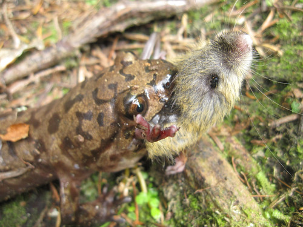

**Image 1:** A Pacific Giant Salamander (Dicamptodon tenebrosus), enjoys its lunch. **Source:** [Industrius Info](https://www.industrious.info/55/08768-pacific-giant-salamander-eating.html)

### **Results**

#### A: Visualizing salamander abundance between old growth and clear cut sections of Mack Creek

[figure not shown]

**Figure 1:** Salamander abundance

#### B: Salamander counts by channel classification

**Table 1:** Salamander counts by channel classification. In 2017, the highest abundance of salamanders in both clear cut (CC) and old growth (OG) forests were found in cascades (67.1% and 62.8%, respectively), followed by side channels (24.5% and 23.1%), and then pools (8.4% and 14.1%).

| Section | Cascade | Pool | Side channel |
| --- | --- | --- | --- |
| Clear cut | 247 (67.1%) | 31 (8.4%) | 90 (24.5%) |
| Old growth | 201 (62.8%) | 45 (14.1%) | 74 (23.1%) |

#### C: Impacts of forest condition of salamander location

In 2017, there is not a significant effect of forest condition (old growth/ clear cut) on where in the channel salamanders are found (cascade/pool/sidechannel) ($\chi$<sup>2</sup>(2) =5.54, *p* = 0.063)

#### E.

[output not shown]

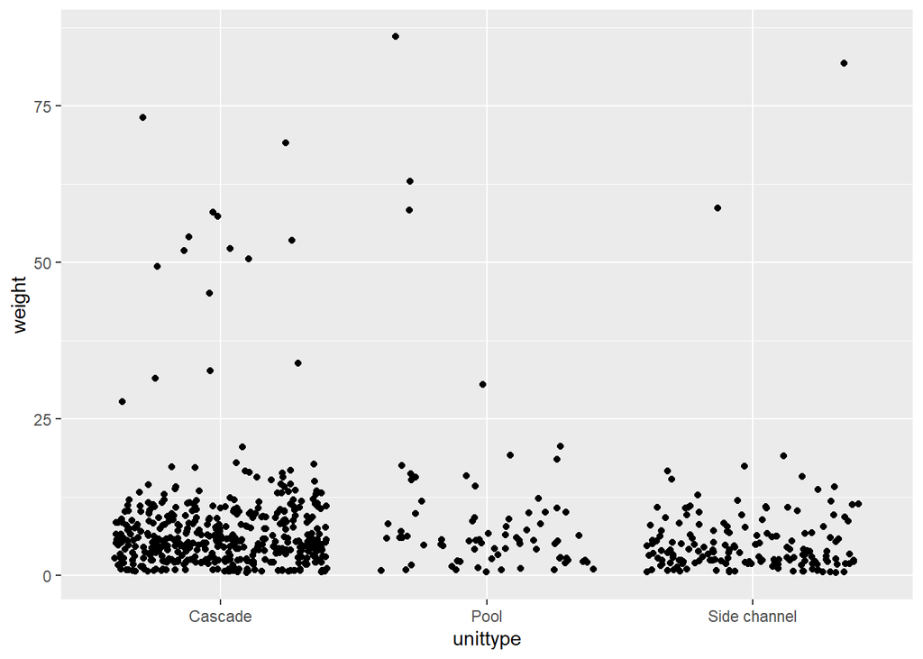

```
##              Df Sum Sq Mean Sq F value Pr(>F)
## unittype      2    757   378.4   4.216 0.0151 *
## Residuals   684  61403    89.8
## ---
## Signif. codes:  0 '***' 0.001 '**' 0.01 '*' 0.05 '.' 0.1 ' ' 1
## 1 observation deleted due to missingness
```

```
##   Tukey multiple comparisons of means
##     95% family-wise confidence level
##
## Fit: aov(formula = weight ~ unittype, data = salamanders_2017)
##
## $unittype
##                           diff        lwr        upr     p adj
## Pool-Cascade          1.776650 -0.9846147  4.5379145 0.2862119
## Side channel-Cascade -1.844204 -3.8759182  0.1875106 0.0841989
## Side channel-Pool    -3.620854 -6.7089770 -0.5327303 0.0166225
```

[output not shown]